# Part I - Ford GoBike System

## Introduction

> This data set contains information about individual rides made in a bike-sharing system covering the greater San Francisco Bay area over a certain period. The dataset contains over 183k records and has details of each ride such as the gender of the rider, the year of birth, destination, duration of trip, user type etc.

## Preliminary Wrangling

```python
# import all packages and set plots to be embedded inline
import numpy as np
import pandas as pd
import matplotlib.pyplot as plt
import seaborn as sb

%matplotlib inline
```

> Load in your dataset and describe its properties through the questions below. Try and motivate your exploration goals through this section.

```python
bikeshare = pd.read_csv('bikeshare-tripdata.csv')
bikeshare.head()
```

|  | duration_sec | start_time | end_time | start_station_id | start_station_name | start_station_latitude | start_station_longitude | end_station_id | end_station_name | end_station_latitude | end_station_longitude | bike_id | user_type | member_birth_year | member_gender | bike_share_for_all_trip |
| --- | --- | --- | --- | --- | --- | --- | --- | --- | --- | --- | --- | --- | --- | --- | --- | --- |
| 0 | 52185 | 32:10.1 | 01:56.0 | 21.0 | Montgomery St BART Station (Market St at 2nd St) | 37.789625 | -122.400811 | 13.0 | Commercial St at Montgomery St | 37.794231 | -122.402923 | 4902 | Customer | 1984.0 | Male | No |
| 1 | 42521 | 53:21.8 | 42:03.1 | 23.0 | The Embarcadero at Steuart St | 37.791464 | -122.391034 | 81.0 | Berry St at 4th St | 37.775880 | -122.393170 | 2535 | Customer | NaN | NaN | No |
| 2 | 61854 | 13:13.2 | 24:08.1 | 86.0 | Market St at Dolores St | 37.769305 | -122.426826 | 3.0 | Powell St BART Station (Market St at 4th St) | 37.786375 | -122.404904 | 5905 | Customer | 1972.0 | Male | No |
| 3 | 36490 | 54:26.0 | 02:36.8 | 375.0 | Grove St at Masonic Ave | 37.774836 | -122.446546 | 70.0 | Central Ave at Fell St | 37.773311 | -122.444293 | 6638 | Subscriber | 1989.0 | Other | No |
| 4 | 1585 | 54:18.5 | 20:44.1 | 7.0 | Frank H Ogawa Plaza | 37.804562 | -122.271738 | 222.0 | 10th Ave at E 15th St | 37.792714 | -122.248780 | 4898 | Subscriber | 1974.0 | Male | Yes |

```python
#view the overall structure of the dataset to know the data types, number of columns and rows etc.
bikeshare.info()
```

```
<class 'pandas.core.frame.DataFrame'>
RangeIndex: 183412 entries, 0 to 183411
Data columns (total 16 columns):
 #   Column                   Non-Null Count   Dtype
---  ------                   --------------   -----
 0   duration_sec             183412 non-null  int64
 1   start_time               183412 non-null  object
 2   end_time                 183412 non-null  object
 3   start_station_id         183215 non-null  float64
 4   start_station_name       183215 non-null  object
 5   start_station_latitude   183412 non-null  float64
 6   start_station_longitude  183412 non-null  float64
 7   end_station_id           183215 non-null  float64
 8   end_station_name         183215 non-null  object
 9   end_station_latitude     183412 non-null  float64
 10  end_station_longitude    183412 non-null  float64
 11  bike_id                  183412 non-null  int64
 12  user_type                183412 non-null  object
 13  member_birth_year        175147 non-null  float64
 14  member_gender            175147 non-null  object
 15  bike_share_for_all_trip  183412 non-null  object
dtypes: float64(7), int64(2), object(7)
memory usage: 22.4+ MB
```

```python
#check for null and NA values
bikeshare.isnull().sum()
```

```
duration_sec                  0
start_time                    0
end_time                      0
start_station_id            197
start_station_name          197
start_station_latitude        0
start_station_longitude       0
end_station_id              197
end_station_name            197
end_station_latitude          0
end_station_longitude         0
bike_id                       0
user_type                     0
member_birth_year          8265
member_gender              8265
bike_share_for_all_trip       0
dtype: int64
```

```python
bikeshare.member_gender.value_counts()
```

```
Male      130651
Female     40844
Other       3652
Name: member_gender, dtype: int64
```

### Data Cleaning observations

I made the following observations from the dataset which will require cleaning.

1. Drop null and NA values from the dataset.
2. Convert the data type of the member_birth_year column from float to Int.
3. Create a member_age column using the member_birth_year provided and limit the records to riders aged 100 or under.
4. Remove 'Other' gender from the member_gender column and retain only records where the gender is male or female.
5. Create a column for duration_hours from the duration_sec column.
6. Remove columns that will not be needed for this analysis such as 'start_time', 'end_time','start_station_id', 'end_station_id', 'end_station_latitude', 'start_station_latitude', 'start_station_longitude', 'end_station_longitude'.

### Code

```python
#drop null and empty rows

bikeshare.dropna(inplace=True)
```

```python
#change the data type for the member_birth_year column to Int

bikeshare['member_birth_year'] = bikeshare['member_birth_year'].astype('str')
bikeshare['member_birth_year'] = bikeshare['member_birth_year'].str.split('.', expand = True).get(0).astype('int')
```

```python
#create a member_age column from the member_birth_year column details and limit rider age to 100 yrs

from datetime import date

bikeshare['member_age'] = date.today().year - bikeshare['member_birth_year']

bikeshare = bikeshare[bikeshare['member_age'] <= 100]
```

```python
#Remove 'Other' gender from the member_gender column and retain only records where the gender is male or female.

bikeshare = bikeshare[bikeshare['member_gender'] != 'Other']
```

```python
#Create a column for duration_hours from the duration_sec column.

bikeshare['duration_hours'] = round(bikeshare['duration_sec']/3600, 2)
```

```python
#drop columns that will not be required for the analysis.

dcols = ['start_station_id', 'end_station_id', 'end_station_latitude', 'start_station_latitude',
         'start_station_longitude', 'end_station_longitude', 'start_time', 'end_time']
bikeshare.drop(dcols, axis=1, inplace=True)
```

### Test

```python
bikeshare.info()
```

```
<class 'pandas.core.frame.DataFrame'>
Int64Index: 171231 entries, 0 to 183411
Data columns (total 10 columns):
 #   Column                   Non-Null Count   Dtype
---  ------                   --------------   -----
 0   duration_sec             171231 non-null  int64
 1   start_station_name       171231 non-null  object
 2   end_station_name         171231 non-null  object
 3   bike_id                  171231 non-null  int64
 4   user_type                171231 non-null  object
 5   member_birth_year        171231 non-null  int64
 6   member_gender            171231 non-null  object
 7   bike_share_for_all_trip  171231 non-null  object
 8   member_age               171231 non-null  int64
 9   duration_hours           171231 non-null  float64
dtypes: float64(1), int64(4), object(5)
memory usage: 14.4+ MB
```

### What is/are the main feature(s) of interest in your dataset?

> The main features I have taken interest in are the user type, member gender and bike share for all trips.

### What features in the dataset do you think will help support your investigation into your feature(s) of interest?

> I believe that the member gender and member age features might help me investigate what dataset to gain more insight into the user type and bike share for all trips features.

## Univariate Exploration

> In this section, investigate distributions of individual variables. If you see unusual points or outliers, take a deeper look to clean things up and prepare yourself to look at relationships between variables.

```python
#create a function to plot categorical univariate charts
def cplot(dat, ft):
    col = sb.color_palette()[0]
    sb.countplot(data=dat, x=dat[ft], color= col, order=dat[ft].value_counts().index);
```

#### Question: What is the distribution of the categorical features (member_gender, user_type, bike_share_for_all_trips)

#### Visualization

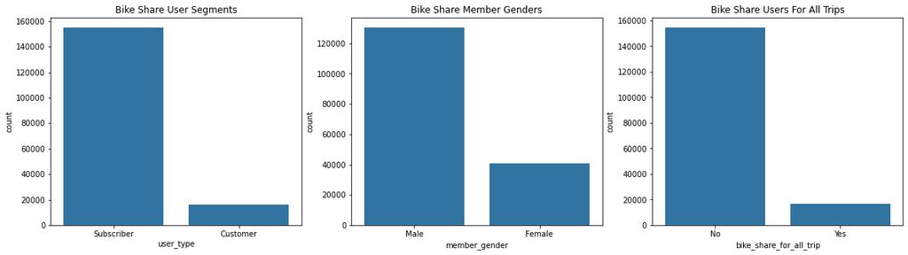

```python
plt.figure(figsize = [20, 5])

plt.subplot(1,3,1)
cplot(bikeshare, 'user_type')
plt.title('Bike Share User Segments')

plt.subplot(1,3,2)
cplot(bikeshare, 'member_gender')
plt.title('Bike Share Member Genders')

plt.subplot(1,3,3)
cplot(bikeshare, 'bike_share_for_all_trip')
plt.title('Bike Share Users For All Trips');
```

#### Question: What is the distribution of the Age of the bike share users and the distribution of the duration of the rides.

#### Visualization

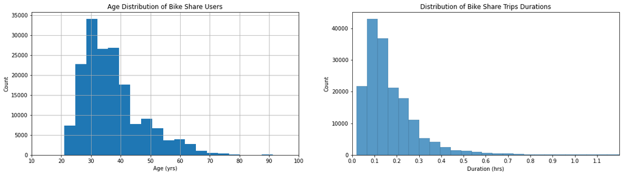

```python
plt.figure(figsize = [20, 5])

plt.subplot(1,2,1)
bikeshare.member_age.hist(bins=20)
plt.xlim([10, 100])
plt.xlabel('Age (yrs)')
plt.ylabel('Count')
plt.xticks(np.arange(10, 101, 10))
plt.title('Age Distribution of Bike Share Users');

plt.subplot(1,2,2)
sb.histplot(bikeshare.duration_hours, bins=500)
plt.xlim([0, 1.2])
plt.xlabel('Duration (hrs)')
plt.xticks(np.arange(0, 1.2, 0.1))
plt.title('Distribution of Bike Share Trips Durations');
```

#### Observations

1. Majority of the bike share users are middle aged people between the ages of 24 and 43.
2. The age group that made the highest number of trips is between 28 and 32 years.
3. The distribution is right skewed with majority of the riders being younger while there are a few outliers with ages 70-90 years also participating in the bike share program.
4. The distribution for the duration of the bike trips is also right skewed with most of the trips lasting 0.3hrs (18 mins) or less while some trips lasted as long as 45 mins to 1hr plus.

#### Question: Which stations are the most popular Start and End destinations.

#### Visualization

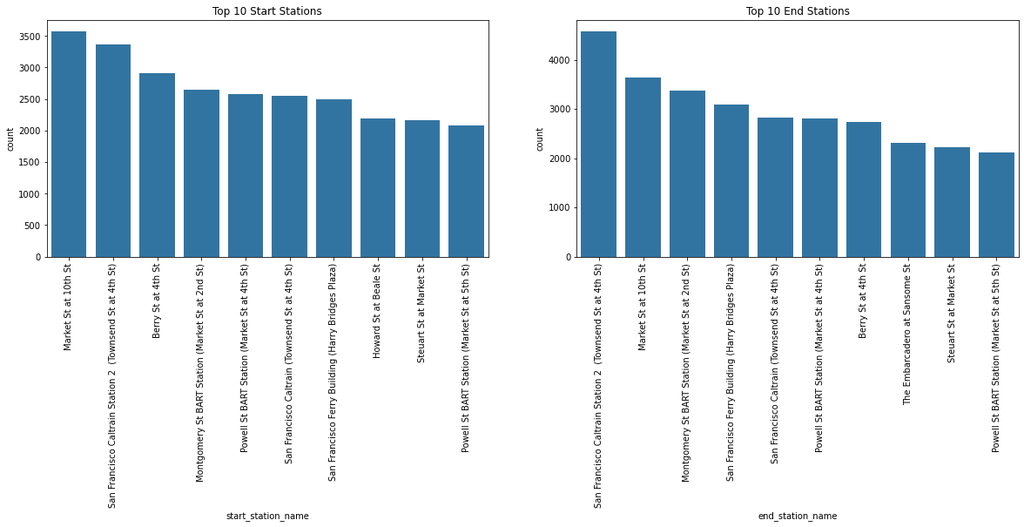

```python
plt.figure(figsize = [20, 5])
col = sb.color_palette()[0]

plt.subplot(1,2,1)
sb.countplot(x = bikeshare.start_station_name, data = bikeshare, color= col,
             order = bikeshare['start_station_name'].value_counts().head(10).index);
plt.xticks(rotation = 90)
plt.title('Top 10 Start Stations');


plt.subplot(1,2,2)
sb.countplot(x = bikeshare.end_station_name, data = bikeshare, color= col,
             order = bikeshare['end_station_name'].value_counts().head(10).index);
plt.xticks(rotation = 90);
plt.title('Top 10 End Stations');
```

#### Observations

There most popular destinations either for starting bike share trips or as destiantions are as follows:

1. Market St at 10th St
2. San Fransisco caltrain station 2
3. Montgomery St. BART station
4. Powell St BART Station
5. San Fransisco ferry building

### Discuss the distribution(s) of your variable(s) of interest. Were there any unusual points? Did you need to perform any transformations?

1. The user type showed that both subscribers and walk-in customers use the bike share program though there were more subscribers than customer.
2. The number of people that use the bike share program for all trips is just a small portion of the overall users.
3. I had to calculate the age of the riders using their date of birth and also conveterd the duration of each ride which was originally captured in seconds to hours to make it easier to understand.
4. In gettting the top 10 start and end locations, I had to limit the output of the data to the 10 with the highest frequency.

### Of the features you investigated, were there any unusual distributions? Did you perform any operations on the data to tidy, adjust, or change the form of the data? If so, why did you do this?

1. The age distribution showed that some of the riders were 80, 90 and above and I would not expect people at this age bracket to be riding bikes. I limited the age bracket to 100 years max during cleaning.
2. The member gender had 'Other' as a gender and the number of occurences was limited hence I removed it during cleaning.

## Bivariate Exploration

> In this section, investigate relationships between pairs of variables in your data. Make sure the variables that you cover here have been introduced in some fashion in the previous section (univariate exploration).

#### Question: Investigate if there are any correlations in the dataset.

#### Visualization

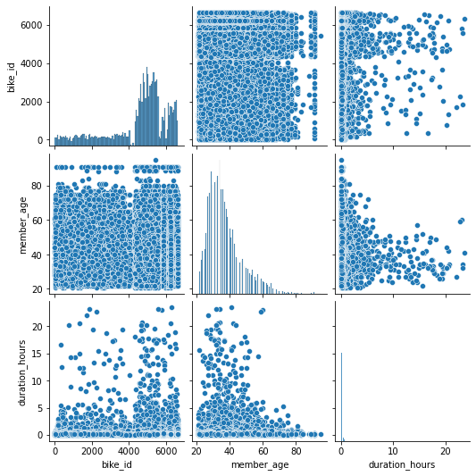

```python
plt.figure(figsize=(40,20));

sb.pairplot(data=bikeshare.drop(['duration_sec', 'member_birth_year'], axis=1));
```

#### Observations

There are no visible correlations from the pair plot above.

#### Question: Investigate the relationship between 2 categorical variables of interest.

#### Visualization

```python
#create a 2nd function to plot categorical bivariate charts
def cplot2(dat2, ft, vr):
    sb.countplot(data=dat2, x=dat2[ft], hue=dat2[vr]);
```

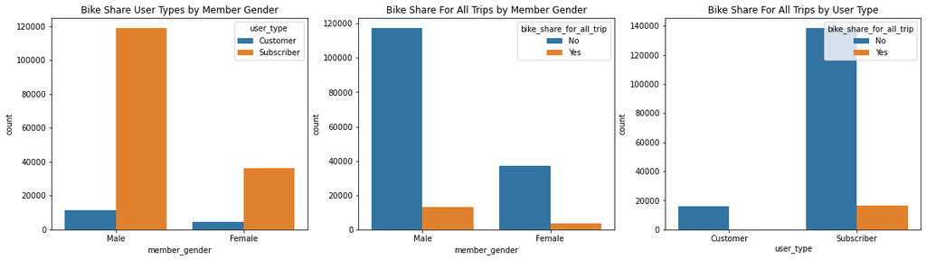

```python
plt.figure(figsize = [20, 5])

plt.subplot(1,3,1)
cplot2(bikeshare, 'member_gender', 'user_type');
plt.title('Bike Share User Types by Member Gender');

plt.subplot(1,3,2)
cplot2(bikeshare, 'member_gender', 'bike_share_for_all_trip');
plt.title('Bike Share For All Trips by Member Gender');

plt.subplot(1,3,3)
cplot2(bikeshare, 'user_type', 'bike_share_for_all_trip');
plt.title('Bike Share For All Trips by User Type');
```

#### Observations

1. There are about 119k Male subscribers compared to the 38k which are Female while there are also more male customers than female.
2. All the customers do not use bike share for all trips while very few of the subscribers (17k) use the bike share services for all trips compared to the (138k) subscribers who do not use bike share for all trips.
3. More males use the bike share service than females.

#### Question: Investigate the relationship between a categorical variable of interest and a numeric variable.

#### Visualization

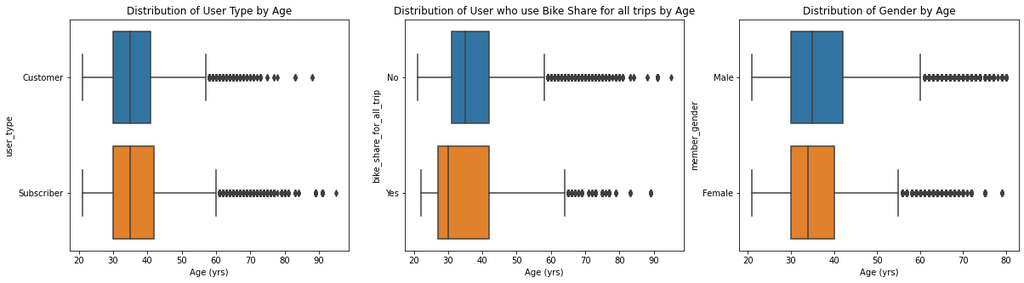

```python
plt.figure(figsize = [20, 5])

plt.subplot(1,3,1)
sb.boxplot(data=bikeshare, y=bikeshare.user_type, x=bikeshare.member_age);
plt.title('Distribution of User Type by Age')
plt.xlabel('Age (yrs)');

plt.subplot(1,3,2)
sb.boxplot(data=bikeshare, x=bikeshare.member_age, y=bikeshare.bike_share_for_all_trip);
plt.title('Distribution of User who use Bike Share for all trips by Age')
plt.xlabel('Age (yrs)');

plt.subplot(1,3,3)
sb.boxplot(data=bikeshare[bikeshare['member_age'] <= 80], x='member_age', y='member_gender');
plt.title('Distribution of Gender by Age')
plt.xlabel('Age (yrs)');
```

#### Observations

1. Majority of the bike share users are aged between 30 and 40 years with their median age being 35yrs.
2. The users who use bikeshare for all trips have an median age of 30 while users who do not have an median age of 35 which suggests that younger people tend to use bike share for all trips.
3. Females who use the bike share service are slightly younger that the males with an median age of 34 while that of males is 35yrs.

#### Question: Further investigate the relationships between the categorical variables of interest and total duration of trips recorded.

#### Visualization

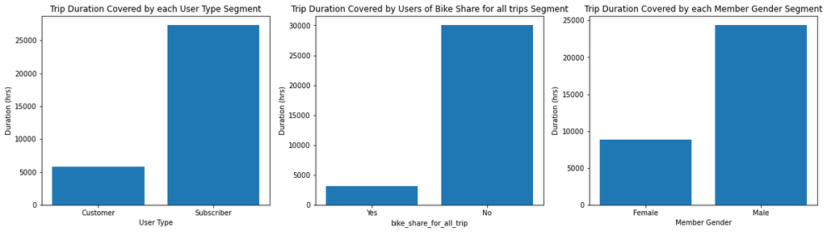

```python
#Generate the grouped data required for this investigation.
x2 = bikeshare.groupby('user_type').sum().sort_values(by='duration_hours').reset_index()
y2 = bikeshare.groupby('bike_share_for_all_trip').sum().sort_values(by='duration_hours').reset_index()
c2 = bikeshare.groupby('member_gender').sum().sort_values(by='duration_hours').reset_index()

#create plots with the grouped data
plt.figure(figsize = [20, 5])

plt.subplot(1,3,1)
plt.bar(x2.user_type, x2.duration_hours);
plt.ylabel('Duration (hrs)')
plt.xlabel('User Type')
plt.title('Trip Duration Covered by each User Type Segment')

plt.subplot(1,3,2)
plt.bar(y2.bike_share_for_all_trip, y2.duration_hours)
plt.ylabel('Duration (hrs)')
plt.xlabel('bike_share_for_all_trip')
plt.title('Trip Duration Covered by Users of Bike Share for all trips Segment')

plt.subplot(1,3,3)
plt.bar(c2.member_gender, c2.duration_hours)
plt.ylabel('Duration (hrs)')
plt.xlabel('Member Gender')
plt.title('Trip Duration Covered by each Member Gender Segment');
```

### Talk about some of the relationships you observed in this part of the investigation. How did the feature(s) of interest vary with other features in the dataset?

1. There were more male bikeshare users than female users.
2. The average age of the bikeshare service users is 35 years while majority are between the ages of 30 to 40 years.
3. There are more bikeshare service subscribers than walk in customers.
4. Most of the bikeshare service users do not use it for all trips.

## Multivariate Exploration

> Create plots of three or more variables to investigate your data even further. Make sure that your investigations are justified, and follow from your work in the previous sections.

#### Question: Investigate the relationship between the member gender, member age, user type and bike_share_for_all_trip.

#### Visualizations

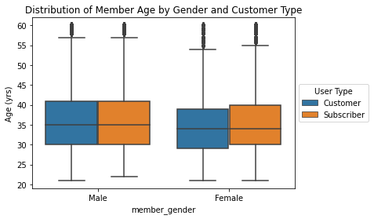

```python
bage = bikeshare[bikeshare['member_age'] <= 60]
sb.boxplot(data = bage, x = 'member_gender', y = 'member_age', hue = 'user_type')
plt.legend(loc = 6, bbox_to_anchor = (1.0, 0.5), title='User Type');
plt.ylabel('Age (yrs)')
plt.title('Distribution of Member Age by Gender and Customer Type');
```

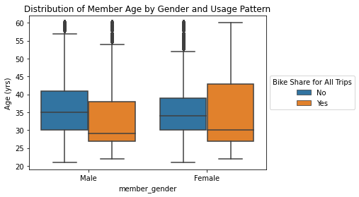

```python
sb.boxplot(data = bage, x = 'member_gender', y = 'member_age', hue = 'bike_share_for_all_trip')
plt.legend(loc = 6, bbox_to_anchor = (1.0, 0.5), title='Bike Share for All Trips');
plt.ylabel('Age (yrs)')
plt.title('Distribution of Member Age by Gender and Usage Pattern');
```

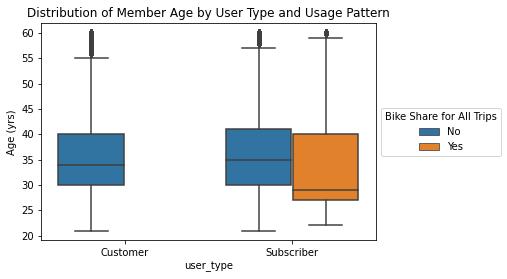

```python
sb.boxplot(data=bage, x=bage.user_type, y=bage.member_age, hue=bage.bike_share_for_all_trip);
plt.legend(loc = 6, bbox_to_anchor = (1.0, 0.5), title='Bike Share for All Trips');
plt.ylabel('Age (yrs)')
plt.title('Distribution of Member Age by User Type and Usage Pattern');
```

#### Observations

1. Majority of the users who do not use the bike share service for all trips fall between the ages of 30 and 40 with a median age of about 34.
2. The male customers and suscribers tend to be older the female counterparts.
3. A higher number of female customers use the bike share service for all trips while the male customers seems to be evenly.
4. Younger customers both male and female (under 30 years) use the bike share service for all trips while the majority of users who do not use the service for all trips are aged between 30-41 years.

### Talk about some of the relationships you observed in this part of the investigation. Were there features that strengthened each other in terms of looking at your feature(s) of interest?

> It is evident that younger users under the age of 31 use the bike share service for all trips. It appears that member age could determine wether they use the bike share service for all trips.

### Were there any interesting or surprising interactions between features?

> The gender and age of the bike share service users seemed to contribute to whether they used the bike share service for all trips.

## Conclusions

1. The bike share service has a lot of users who are either subscribers or walk in customer though the number of subscribers is higher than the walk in customers.
2. The bike share services has more of male users compared to female users.
3. Majority of the bike share users are middle aged people between the ages of 21 and 43.
4. Though the about 90% of the bike share users are subscribers while very little account for walk in customers, just very few (10%) use the bike share servcie for all trips while 90% of the users which cuts accross subscribers and customers do not use the service for all trips.
5. There are more males than females who do not use the service for all trips.
6. Younger customers both male and female (under 30 years) use the bike share service for all trips while the majority of users who do not use the service for all trips are aged between 30-41 years.